# COVID-19 Research Project

### BIOL390: Reproducible Research, Summer 2020

**Copyright © (2020) Bethany Riess**

## A. Abstract (tl;dr)

COVID-19 research project evaluating the COVID-19 trends from states that never issued stay-at-home orders compared to states that did. The information gathered for this project took place from the beginning of the pandemic until August 16th, 2020.

## B. Introduction

COVID-19 (*Orthocoronavirinae*) is the name given to the virus that has caused a pandemic starting at the end of 2019. This virus is also known as SARS‑CoV‑2.First identified in December of 2019, the virus outbreak began in Wuhan, China and quickly spread throughout the globe. The World Health Organization (WHO) declared it an International Public Health Emergency [^1] , and many states in the United States responded quickly, implementing regulations in hope of decreasing the spread of COVID-19, and slowing its effect on the population. Some states chose to shut down almost entirely, closing gyms, theaters, bowling alleys, restaurants, and much more. While many states were quick to issue stay-at-home orders, some states were determined to remain more open for the height of the pandemic. Seven states chose not to issue stay-at-home orders during the pandemic. These states were Arkansas, Iowa, Nebraska, North Dakota, South Dakota, Utah, and Wyoming.One of these states, South Dakota, did not even require the closure of any businesses (although in-person education at schools was closed in all 7 states.)[^2]

## C. Hypothesis

The intention of the stay-at-home orders was to limit interactions from members of the population in hopes of avoiding contact that would spread COVID-19. Based on this idea, the states that did not issue stay-at-home orders should have higher rates of COVID-19 cases than the states that did issue a stay-at-home order.

## D. Datasets used

The primary dataset used for this analysis is the “United States COVID-19 Cases and Deaths by State” compiled by the CDC and published on Data.CDC.gov[^3].Additionaly, the dataset “United States by Density” was collected from [World Population Review](https://worldpopulationreview.com/state-rankings/state-densities), which compiled the dataset based off US Census state population estimates.[^4]

## E. Description of analyses

Seven states chose not to implement a stay-at-home order during the beginning of the COVID-19 pandemic. Under the assumption that the stay-at-home orders would reduce contact between people in a population, it could by hypothesized that the states which did implement the order would have less deaths than the states which did not. Figure 1, below, shows the total deaths per state. In this figure, the states with black dots are the state which did implement the order, while the dots in red mark the total deaths for the states which did not implement the order. On a log scale we can see that the states which did not implement the order had generally less fatalities than the states that did.

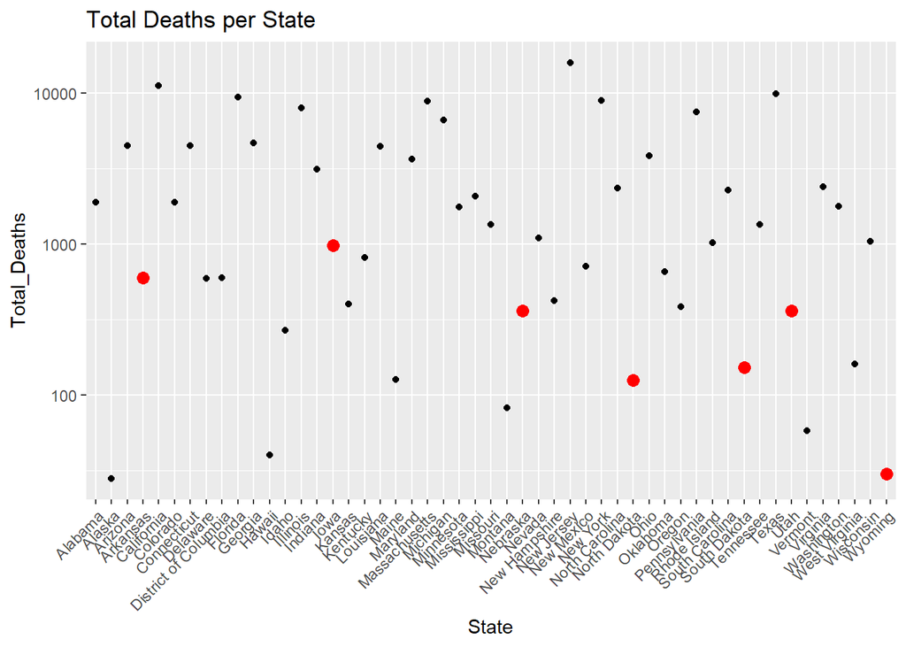

**Figure 1:** Total deaths per state. States that did not implement a stay-at-home order are red.

Total deaths in not a true indicator of effectiveness for the stay-at-home order, however, because other factors can play into the totals, such state size, population, and population density. A slightly better indicator of effectiveness of the stay-at-home order can be seen in Figure 2 below. Looking at Total Deaths per 100,000 people demonstrates fatality rates with more consideration of the population size. The black dots in the figure represent states that implemented a stay-at-home order and the red dots represent states that did not.

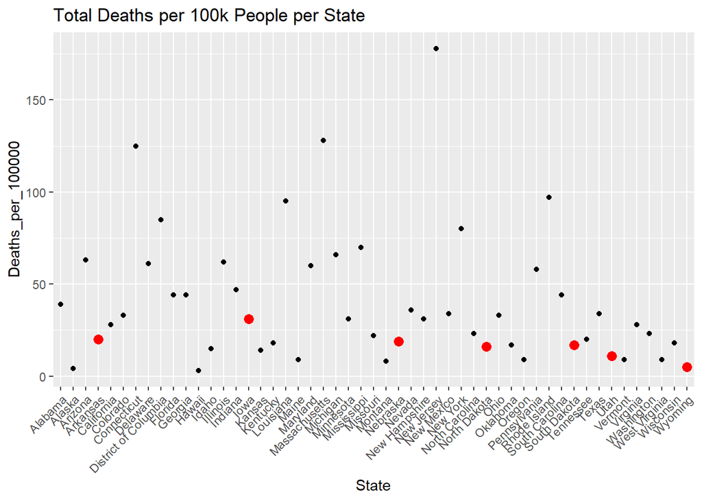

**Figure 2:** Total deaths per 100k people per state. States that did not implement a stay-at-home order are in red

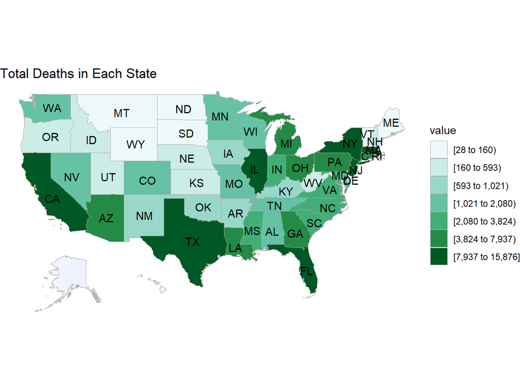

**Figure 3:** Total deaths in each state.

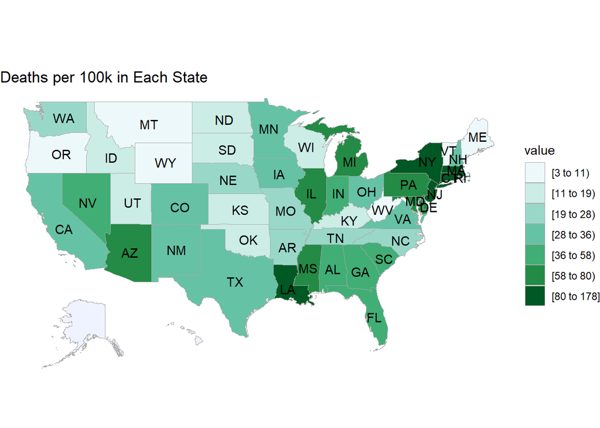

**Figure 4:** Deaths per 100k people in each state.

Comparing the two graphs below to the two graphs above we can see that most of the states which did not issue a stay-at-home order are also the states with lower populations and lower population densities. The states that had lower population densities are also the states that typically had lower fatality rates regardless of stay-at-home status.

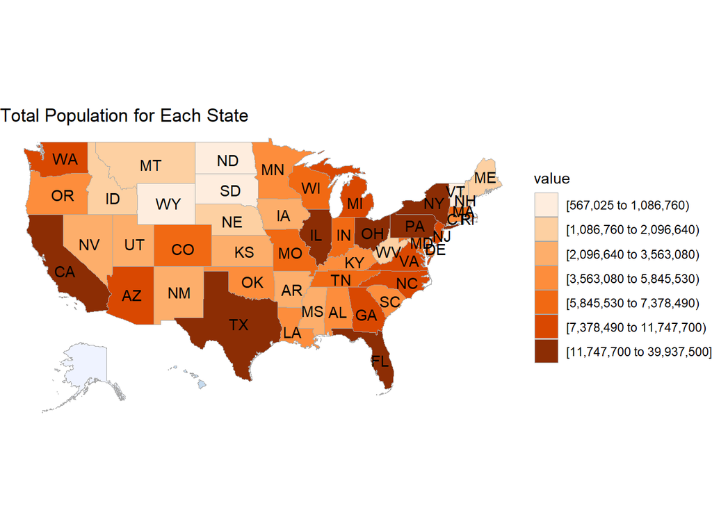

**Figure 5:** Total population in each state.

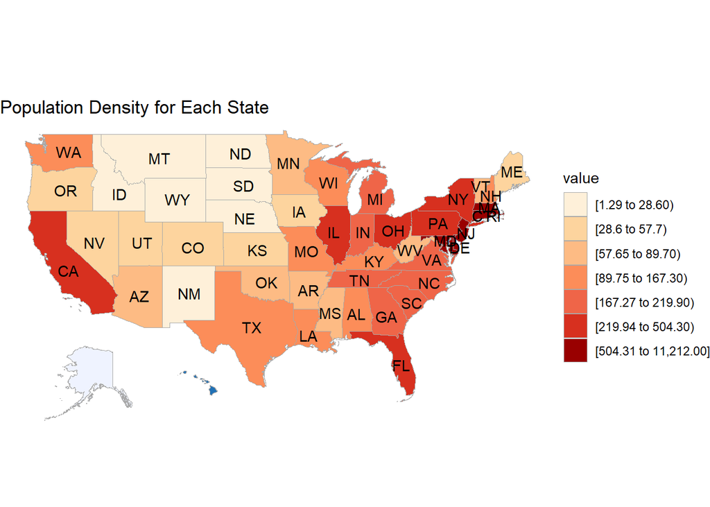

**Figure 6:** Population density in each state.

## F. Conclusions

In conclusion, it would appear that states without a stay-at-home order did generally better than state with one. However, there are apparent trends in the success of states with low populations and low population densities. Additionally, the states that did not issue a stay-at-home order were also more likely to be states that had low populations and low population densities. Given the data, the null hypothesis cannot be rejected and the stay-at-home orders may or may not have been effective.

## G. Viewing this project

The completed project files can be accessed online at (https://github.com/riessb12/COVID-19). The repo for this reproducible project is also publicly available at (https://riessb12.github.io/).

[^1]: COVID-19 pandemic. (2020, August 14). Retrieved August 17, 2020, from https://en.wikipedia.org/wiki/COVID-19_pandemic
[^2]: States that did not issue stay-at-home orders in response to the coronavirus (COVID-19) pandemic, 2020. (n.d.). Retrieved August 16, 2020, from https://ballotpedia.org/States_that_did_not_issue_stay-at-home_orders_in_response_to_the_coronavirus_(COVID-19)_pandemic,_2020
[^3]: United States COVID-19 Cases and Deaths by State. (n.d.). Retrieved August 16, 2020, from https://www.cdc.gov/covid-data-tracker/
[^4]: United States by Density 202. (n.d.). Retrieved August 16, 2020, from https://worldpopulationreview.com/state-rankings/state-densities